# Quantitative methods 1: Data collection

SKOC39: Introduction to research methods  
and academic writing

nils.holmberg@isk.lu.se

## Presentation

- Nils Holmberg
- Computational  
  content analysis
- Cognitive  
  communication effects

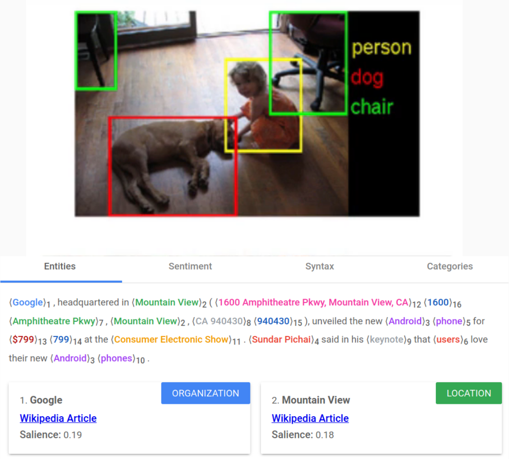

## Quantitative methods

- 9. Experiments and  
     Threats to Validity
- 10. Survey Research,  
      Questionnaire
- 11. Quantitative  
      Content Analysis


## Course literature

[figure not shown]

Boyle and Schmierbach (2015)

[figure not shown]

Boyle and Schmierbach (2019)

## Lectures and workshops

Data collection (nov 12)

- 5. Concept Explication and Measurement
- 6. Reliability and Validity
- 7. Effective Measurement
- 8. Sampling
- 11. Content Analysis

Exam question 1

Data analysis (nov 26)

- 9. Experiments and Threats to Validity
- 10. Survey Research
- 14. Descriptive Statistics
- 15. Inferential Statistics
- 16. Multivariate Statistics

Exam question 2

## 5. Concept Explication and Measurement

- Conceptual Definition (p. 104)
- Operational Definition (p. 107)
- Dimension (p. 105)
- Indicator (p. 108)
- Nominal-Level Measure (p. 111)
- Ordinal-Level Measure (p. 112)
- Interval-Level Measure (p. 113)
- Ratio-Level Measure (p. 114)

## Operational Definition (p. 107)

#### 5. Concept Explication and Measurement

## Dimension (p. 105)

#### 5. Concept Explication and Measurement

## Indicator (p. 108)

#### 5. Concept Explication and Measurement

## Nominal-Level Measure (p. 111)

#### 5. Concept Explication and Measurement

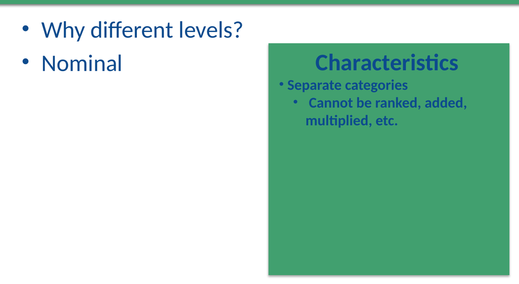

## Ordinal-Level Measure (p. 112)

#### 5. Concept Explication and Measurement

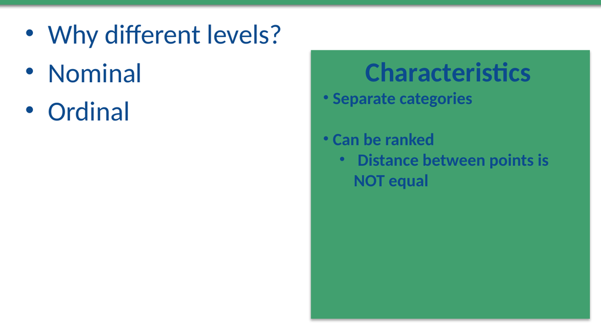

## Interval-Level Measure (p. 113)

#### 5. Concept Explication and Measurement

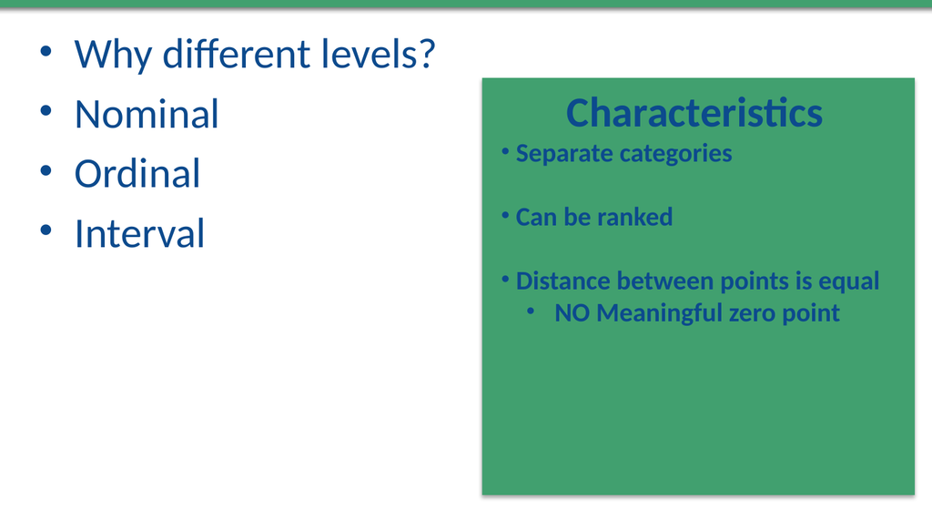

## Ratio-Level Measure (p. 114)

#### 5. Concept Explication and Measurement

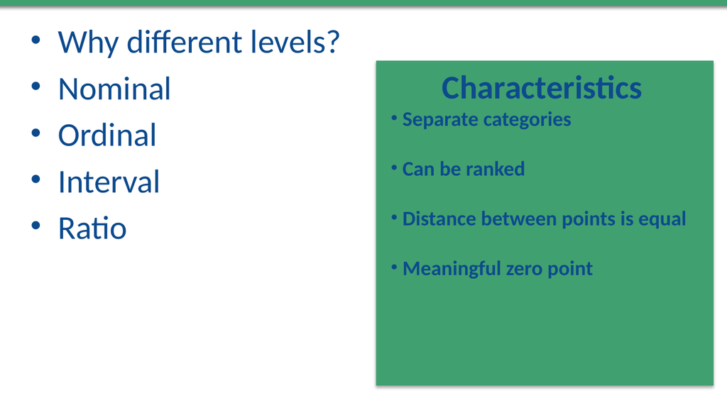

## 6. Reliability and Validity

- Random Error (p. 125)
- Systematic Error (p. 126)
- Test-Retest Reliability (p. 131)
- Construct Validity (p. 132)
- External Validity/Generalizability (p. 139)

## Random Error (p. 125)

#### 6. Reliability and Validity

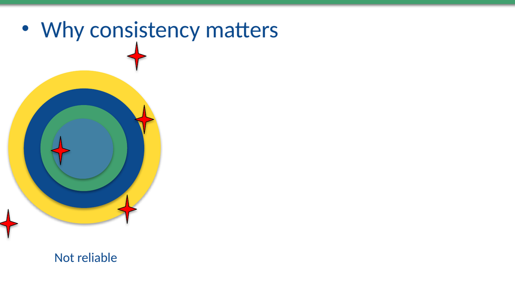

## Systematic Error (p. 126)

#### 6. Reliability and Validity

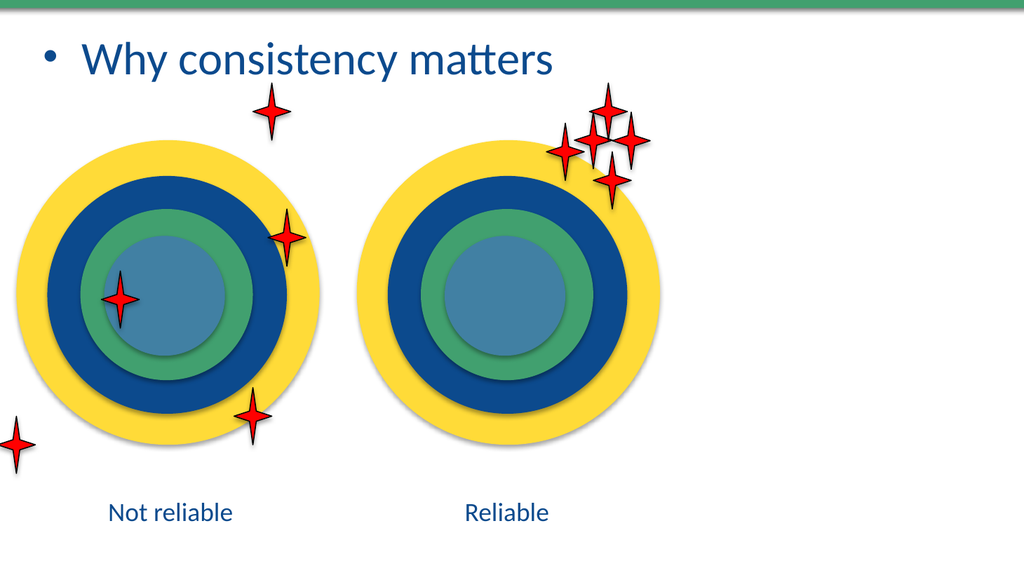

## Test-Retest Reliability (p. 131)

#### 6. Reliability and Validity

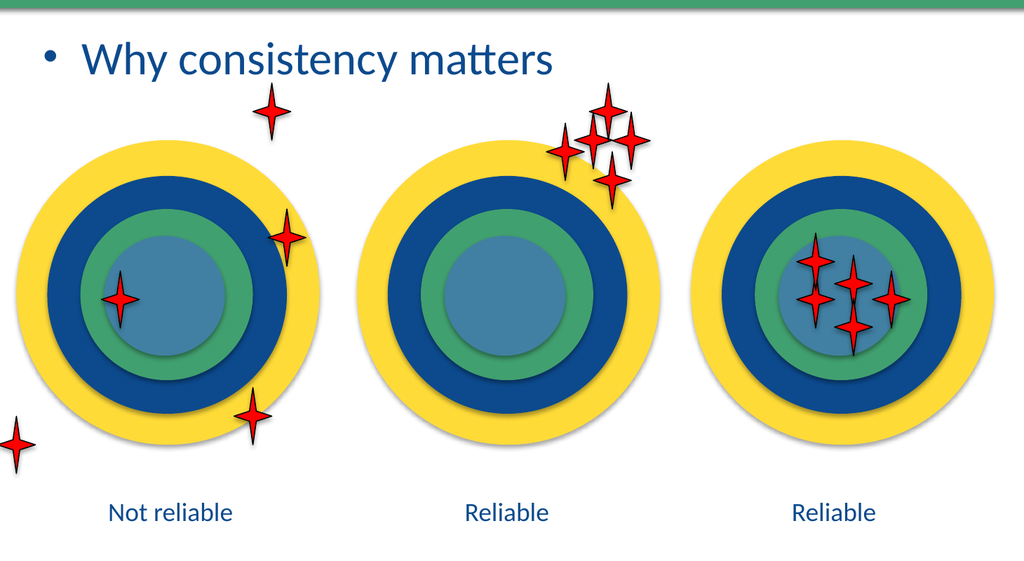

## Content, Construct Validity (p. 132)

#### 6. Reliability and Validity

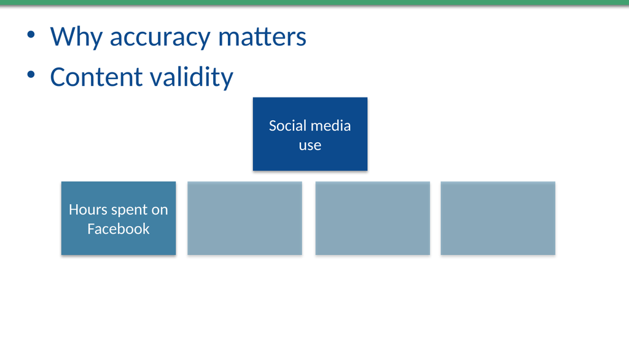

## External Validity/Generalizability (p. 139)

#### 6. Reliability and Validity

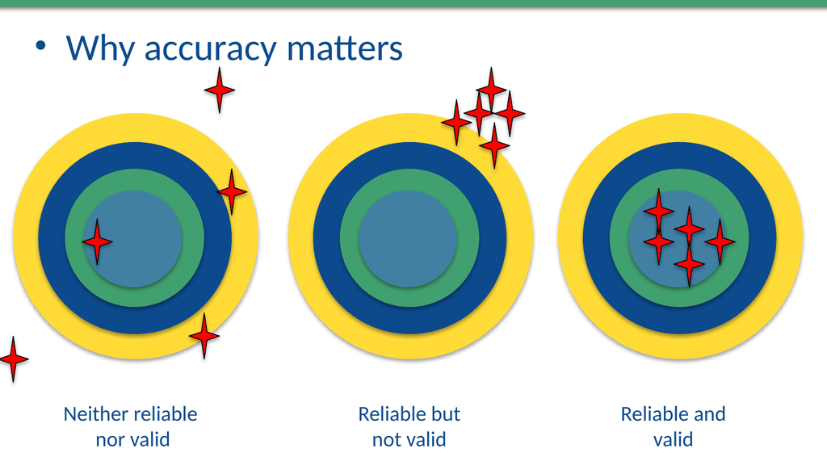

## 7. Effective Measurement

- Direct and Indirect Observation (p. 155)
- Self-Report (p. 156)
- Questionnaire Design (p. 162)
- Closed-Ended (p. 170)
- Exhaustive (p. 172)
- Mutually Exclusive (p. 173)
- Leading Questions (p. 174)
- Social Desirability (p. 175)
- Clarity (p. 176)
- Double-Barreled (p. 177)
- Likert-Type Items (p. 178)

## Direct and Indirect Observation (p. 155)

#### 7. Effective Measurement

- **Definition**:
  - Direct observation involves the researcher watching and recording behaviors or phenomena as they occur.
  - Indirect observation relies on records, artifacts, or reports rather than firsthand observation.
- **Explanation**:
  - Direct observation is often used in natural settings to minimize interference.
  - Indirect observation is useful when direct observation is not feasible (e.g., historical records).
- **Examples**:
  - **Direct**: Observing traffic patterns at an intersection.
  - **Indirect**: Analyzing security footage to understand customer behaviors.

## Self-Report (p. 156)

#### 7. Effective Measurement

- **Definition**:
  - A method where respondents provide data about themselves, often through surveys or interviews.
- **Explanation**:
  - Common in psychological and sociological studies to understand attitudes, beliefs, or experiences.
  - Relies on the honesty and self-awareness of participants.
- **Examples**:
  - Surveys about consumer satisfaction.
  - Diaries tracking daily physical activity.

## Questionnaire Design (p. 162)

#### 7. Effective Measurement

- **Definition**:
  - A set of written digital questions used to collect data systematically.
- **Explanation**:
  - Can include open-ended, closed-ended, or a mix of question types.
  - Suitable for large-scale data collection due to efficiency.
- **Examples**:
  - Online polls measuring user satisfaction.
  - Employee feedback surveys conducted anonymously.

## Closed-Ended (p. 170)

#### 7. Effective Measurement

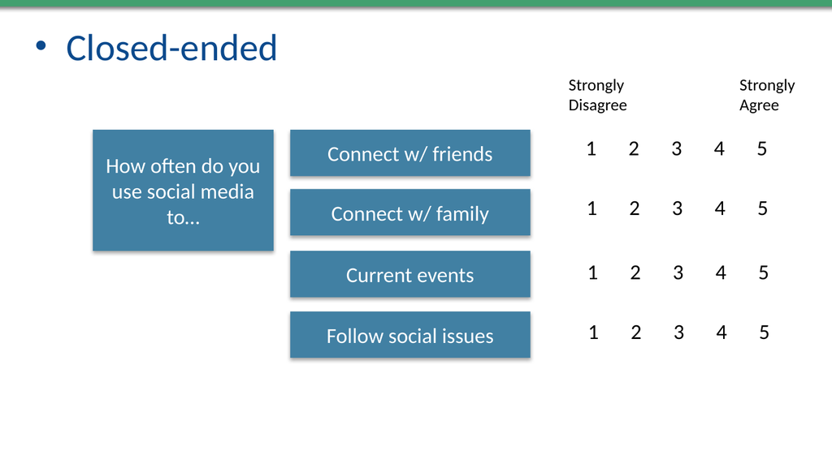

## Exhaustive (p. 172)

#### 7. Effective Measurement

- **Definition**:
  - A characteristic of response options where all possible answers are covered.
- **Explanation**:
  - Ensures that every respondent can find an appropriate option.
  - Reduces frustration and increases accuracy.
- **Examples**:
  - Adding an “Other (please specify)” option in a list of job categories.
  - Including all demographic groups in a survey about income levels.

## Mutually Exclusive (p. 173)

#### 7. Effective Measurement

- **Definition**:
  - A characteristic where response options do not overlap.
- **Explanation**:
  - Prevents confusion and ensures respondents can select only one correct option.
- **Examples**:
  - Age ranges like 18–24, 25–34 (not 18–25, 25–35).
  - Income brackets clearly separated by ranges without overlap.

## Leading Questions (p. 174)

#### 7. Effective Measurement

- **Definition**:
  - Questions that subtly influence respondents to answer in a specific way.
- **Explanation**:
  - Can bias results and reduce the validity of data.
  - Should be avoided in neutral research designs.
- **Examples**:
  - “Don’t you think our product is amazing?”
  - “How much do you love our new feature?”

## Social Desirability (p. 175)

#### 7. Effective Measurement

- **Definition**:
  - The tendency of respondents to answer in a way they believe is socially acceptable or favorable.
- **Explanation**:
  - Can lead to overreporting of positive behaviors and underreporting of negative ones.
- **Examples**:
  - Claiming higher frequency of exercise than actual.
  - Underreporting alcohol consumption in health surveys.

## Clarity (p. 176)

#### 7. Effective Measurement

- **Definition**:
  - The quality of being easily understood, crucial for effective question design.
- **Explanation**:
  - Avoids ambiguity and ensures respondents interpret questions as intended.
- **Examples**:
  - Clear: “How many times do you exercise per week?”
  - Unclear: “Do you exercise regularly?”

## Double-Barreled (p. 177)

#### 7. Effective Measurement

- **Definition**:
  - A question that asks about two or more issues at once, making it difficult to answer accurately.
- **Explanation**:
  - Should be avoided as it confuses respondents and invalidates data.
- **Examples**:
  - “Do you like our product and recommend it to others?”
  - Better: Separate into “Do you like our product?” and “Would you recommend it to others?”

## Likert-Type Items (p. 178)

#### 7. Effective Measurement

- **Definition**:
  - Questions that ask respondents to rate their level of agreement, frequency, or intensity on a scale.
- **Explanation**:
  - Typically uses a 5- or 7-point scale, enabling nuanced responses.
  - Useful for measuring attitudes or opinions.
- **Examples**:
  - “I am satisfied with the service: Strongly Disagree – Strongly Agree.”
  - “How often do you use the product? Never – Very Often.”

## 8. Sampling

- Representative Sample (p. 189)
- Response Rate (p. 190)
- Sample Size (p. 192)
- Margin of Error (p. 200)
- Simple Random Sampling (p. 211)
- Convenience Sampling (p. 204)
- Snowball Sampling (p. 207)
- Stratified Sampling (p. 213)
- Systematic Sampling (p. 214)

## Population and Sample

#### 8. Sampling

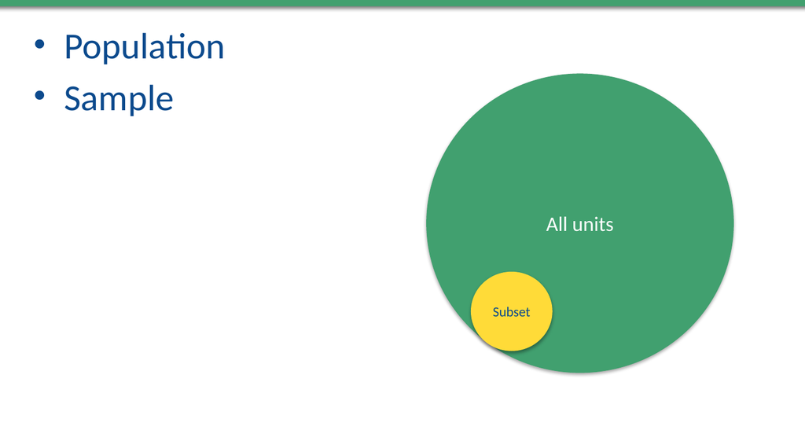

## Representative Sample (p. 189)

#### 8. Sampling

- **Definition**:
  - A subset of a population that accurately reflects the characteristics of the whole population.
- **Explanation**:
  - Ensures that findings from the sample can be generalized to the larger population.
  - Achieved through careful selection methods, avoiding bias.
- **Examples**:
  - A representative sample for a national survey might include participants from various age groups, genders, and regions.
  - Political polls that proportionally include urban, suburban, and rural voters.

## Response Rate (p. 190)

#### 8. Sampling

- **Definition**:
  - The percentage of people who complete a survey out of those who were invited to participate.
- **Explanation**:
  - Higher response rates increase the reliability and representativeness of the data.
  - Low response rates may indicate nonresponse bias, where certain groups are underrepresented.
- **Examples**:
  - A 70% response rate in a customer satisfaction survey is considered excellent.
  - Response rates for online surveys are often lower than for phone interviews.

## Sample Size (p. 192)

#### 8. Sampling

- **Definition**:
  - The number of individuals or units included in a sample.
- **Explanation**:
  - Larger sample sizes generally provide more accurate results and reduce the margin of error.
  - Determining the appropriate sample size depends on the study’s goals, population size, and desired precision.
- **Examples**:
  - A study on consumer preferences with a sample size of 1,000 participants.
  - A clinical trial with a smaller sample size due to high costs or limited availability of patients.

## Margin of Error (p. 200)

#### 8. Sampling

- **Definition**:
  - The range within which the true value for the population is likely to fall, given the sample data.
- **Explanation**:
  - Smaller margins of error indicate greater precision in the results.
  - Dependent on sample size and variability in the population.
- **Examples**:
  - A survey reporting 60% approval with a margin of error of ±3%.
  - Election polls with a margin of error of ±2%, indicating greater reliability.

## Convenience Sampling (p. 204)

#### 8. Sampling (Non-Probability)

- **Definition**:
  - A sampling method where participants are selected based on their availability and accessibility.
- **Explanation**:
  - Easy to implement but often lacks representativeness and introduces bias.
- **Examples**:
  - Surveying students in a classroom because they are readily available.
  - Collecting data from customers visiting a store during a specific time frame.

## Snowball Sampling (p. 207)

#### 8. Sampling (Non-Probability)

- **Definition**:
  - A sampling technique where existing participants recruit additional participants from their networks.
- **Explanation**:
  - Useful for studying hard-to-reach populations but may lead to sampling bias.
- **Examples**:
  - Researching social behaviors in underground communities by having initial participants invite others.
  - Studying experiences of rare disease patients through patient advocacy groups.

## Simple Random Sampling (p. 211)

#### 8. Sampling (Probability)

- **Definition**:
  - A sampling method where every member of the population has an equal chance of being selected.
- **Explanation**:
  - Ensures unbiased selection and representativeness but can be resource-intensive for large populations.
- **Examples**:
  - Drawing names from a hat to select participants.
  - Using a random number generator to pick survey respondents.

## Stratified Sampling (p. 213)

#### 8. Sampling (Probability)

- **Definition**:
  - A sampling method that divides the population into subgroups (strata) and selects samples from each subgroup.
- **Explanation**:
  - Ensures representation of key subgroups, improving accuracy in estimating population parameters.
- **Examples**:
  - Dividing a population by age groups and sampling proportionally from each group.
  - Ensuring representation of urban, suburban, and rural areas in a political poll.

## Systematic Sampling (p. 214)

#### 8. Sampling (Probability)

- **Definition**:
  - A method where every nth individual or unit is selected from a list or population.
- **Explanation**:
  - Simple to implement and ensures even distribution, but may introduce bias if the list has hidden patterns.
- **Examples**:
  - Selecting every 10th customer from a queue for a feedback survey.
  - Picking every 5th household from a neighborhood list for a census.

## 11. Content Analysis

- Intercoder Statistics (p. 294)
- Challenge of Coding (p. 295)
- Social Artifacts (p. 297)
- Latent Content (p. 298)
- Manifest Content (p. 299)

## Intercoder Statistics (p. 294)

#### 11. Content Analysis

- **Definition**:
  - Metrics used to measure the agreement or reliability among coders when analyzing content. Common statistics include Cohen’s Kappa and Krippendorff’s Alpha.
- **Explanation**:
  - Ensures that coding is consistent and not overly influenced by individual bias.
  - High intercoder reliability indicates that the coding scheme is well-defined and reproducible.
- **Examples**:
  - Using Krippendorff’s Alpha to assess agreement on whether social media posts are categorized as positive, neutral, or negative.
  - Measuring intercoder reliability when coding news articles for instances of bias.

## Challenge of Coding (p. 295)

#### 11. Content Analysis

- **Definition**:
  - Difficulties faced in the process of assigning codes to content, often due to ambiguity or subjectivity.
- **Explanation**:
  - Challenges arise from unclear coding guidelines, complex content, or coder biases.
  - Effective training, clear definitions, and pilot testing can mitigate these challenges.
- **Examples**:
  - Ambiguity in defining what constitutes “hate speech” in social media posts.
  - Coders interpreting “aggressive tone” differently when analyzing political debates.

## Social Artifacts (p. 297)

#### 11. Content Analysis

- **Definition**:
  - Products of social interaction or behavior that can be analyzed in content analysis, such as texts, images, videos, or cultural symbols.
- **Explanation**:
  - These artifacts serve as tangible evidence of social processes, values, or norms.
  - Studying them helps researchers understand underlying societal patterns.
- **Examples**:
  - Analyzing advertisements as social artifacts to understand gender role representation.
  - Studying tweets as artifacts of public opinion on political issues.

## Latent Content (p. 298)

#### 11. Content Analysis

- **Definition**:
  - The underlying meaning or implicit themes within a piece of content.
- **Explanation**:
  - Involves subjective interpretation to identify hidden messages or connotations.
  - More nuanced and requires greater coder training compared to manifest content.
- **Examples**:
  - Analyzing latent content in a political speech to identify ideological bias.
  - Identifying implicit cultural values in films or television shows.

## Manifest Content (p. 299)

#### 11. Content Analysis

- **Definition**:
  - The explicit, observable content within a message, such as words, phrases, or images.
- **Explanation**:
  - Easier to quantify and analyze as it requires minimal interpretation.
  - Often used in the initial stages of content analysis before delving into latent content.
- **Examples**:
  - Counting the number of times the word “freedom” appears in political speeches.
  - Analyzing the frequency of product placements in a series of movies.

## Next steps

**Workshop 1, nov 19**

- Content databases, e.g.: https://app.retriever-info.com/
- Coding scheme, survey: https://survey.mailing.lu.se/Admin/

**Lecture 2, nov 26**

- Data analysis software: https://www.jamovi.org/download.html

**References**

Boyle, Michael, and Mike Schmierbach. 2015. *Applied Communication Research Methods: Getting Started as a Researcher*. Routledge.

———. 2019. *Applied Communication Research Methods: Getting Started as a Researcher*. Routledge.

## Pretty Code

```python
import seaborn as sns

# Load the iris dataset
df = sns.load_dataset("iris")

# Display the first 5 rows
df.head()
```

[output not shown]

https://canvas.education.lu.se/courses/28874